# Analysis of Variance

ANOVA (Analysis of Variance) is used to compare multiple means.  
Suppose we have $k$ groups $(k \geqslant 3)$ and each group is given a treatment.

The ANOVA model is:

$$Y_{ij} = \mu + \tau_i + \varepsilon_{ij}, \quad \varepsilon_{ij} \sim
N(0, \sigma^2)$$

Where:  
- $Y_{ij}$: outcome on unit $j$ in group $i$  
- $\mu$: overall mean  
- $\tau_i$: treatment-specific effect for group $i$  
- $\varepsilon_{ij}$: error term, assumed normally distributed  
- $\mu_i = \mu + \tau_i$: group mean

The equivalent form of the ANOVA model is:

$$Y_{ij} = \mu_i + \varepsilon_{ij}, \quad \varepsilon_{ij} \sim
\mathcal{N}(0, \sigma^2)$$

$$\begin{array}{c|c|c|c|c}
\text{Group 1} & \text{Group 2} & \cdots & \text{Group } K
\\
\hline
X_{11} & X_{21} & \cdots & X_{K1} \\
X_{12} & X_{22} & \cdots & X_{K2} \\
\vdots & \vdots & \ddots & \vdots \\
X_{1n_1} & X_{2n_2} & \cdots & X_{Kn_K} \\
\hline
\bar{X}_1 & \bar{X}_2 & \cdots & \bar{X}_K \\
S_1^2 & S_2^2 & \cdots & S_K^2 \\
n_1 & n_2 & \cdots & n_K \\
\end{array}$$

Where:  
- $\bar{X}_i$: sample mean of group $i$  
- $S_i^2$: sample variance of group $i$  
- $n_i$: sample size of group $i$

**Total Sample Size and Overall Mean**

Total sample size:

$$n = n_1 + n_2 + \cdots + n_k$$

Overall sample mean:

$$\bar{X} = \frac{1}{n} \sum_{i=1}^k \sum_{j=1}^{n_i} X_{ij} = \frac{1}{n}
\sum_{i=1}^k n_i \bar{X}_i$$

**Sources of Variation**

Variation **within** groups (SSW / SSE):

$$\text{SSE} = \sum_{i=1}^k (n_i - 1) \cdot S_i^2$$

This represents **error** or **residual** variation.

Variation **between** groups (SSB / SSTr):

$$\text{SSTr} = \sum_{i=1}^k n_i \cdot (\bar{X}_i - \bar{X})^2$$

This captures the **treatment effect** (how group means differ from overall mean).

**Total Variation**

$$\text{SSTotal} = \sum_{i=1}^k \sum_{j=1}^{n_i} (X_{ij} - \bar{X})^2$$

**Decomposition Identity**

$$\text{SSTotal} = \text{SSTr} + \text{SSE}$$

**ANOVA Table**

| Source | df | SS | MS | F-Statistic |
| --- | --- | --- | --- | --- |
| Treatment | k - 1 | SSTr | MSTr = SSTr / (k - 1) | F* = MSTr / MSE |
| Error | n - k | SSE | MSE = SSE / (n - k) |  |
| Total | n - 1 | SSTotal |  |  |

Where $MS = \dfrac{SS}{df}$

**Hypothesis Test**
$$\begin{aligned}
H_0\!: &\quad \mu_1 = \mu_2 = \cdots = \mu_k \\
&\quad \text{(all means are equal → all treatments equally
effective)} \\
\\
H_a\!: &\quad \text{At least one } \mu_j \text{ (for } j = 1, \dots,
k\text{) is different} \\
&\quad \text{(→ at least one treatment has a different effect)}
\end{aligned}$$

**Test Statistic**

$$F^* = \frac{\text{MSTr}}{\text{MSE}} = \frac{\text{SSTr} / (k -
1)}{\text{SSE} / (n - k)} \sim F_{(k - 1,\ n - k)}$$

**Reference Distribution**

The test statistic follows an $F$-distribution with:

- numerator degrees of freedom = $k - 1$
- denominator degrees of freedom = $n - k$

**P-value**

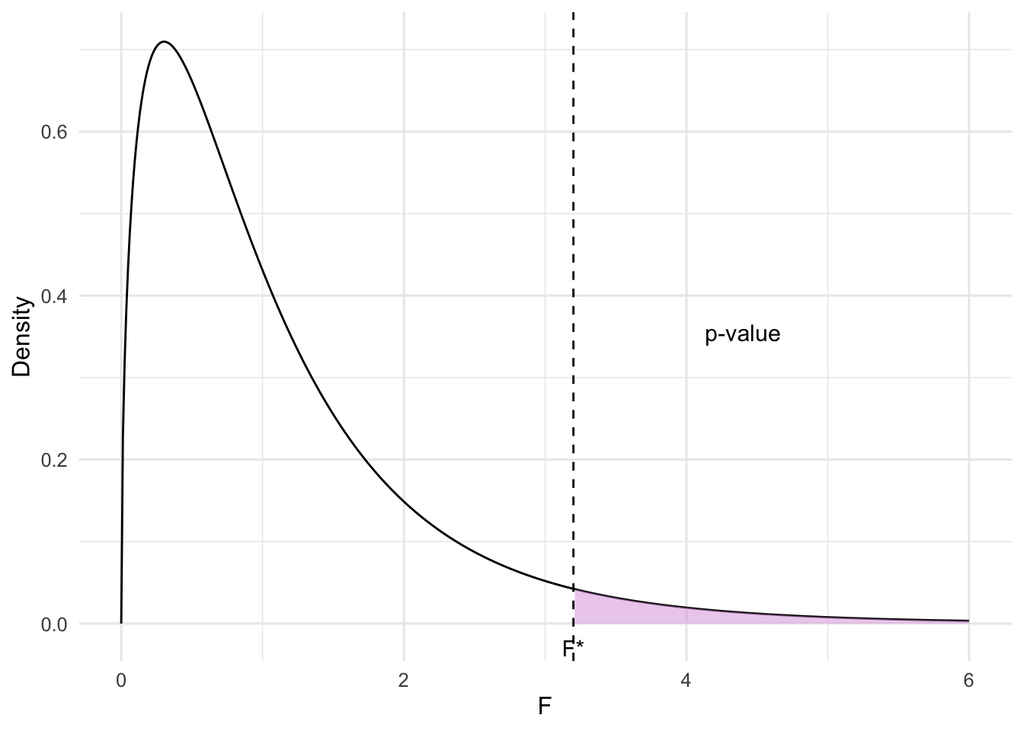

F-distribution with shaded p-value area

**The Data Matrix**

The following table shows last year’s sales data for a small business. The sample is put into a matrix format in which each of the three columns corresponds to one of the three countries in which the company does business. The numbers in the cell represent the sales (in units of $\$ 1000$ ) made in that country last year. These data will be used to develop the theory underlying **Analysis of Variance**, or, for short, **ANOVA**.

|  | Country A | Country B | Country C |
| --- | --- | --- | --- |
|  | 6 | 10 | 14 |
|  | 10 | 8 | 13 |
|  | 7 | 12 | 11 |
|  | 9 | 10 | 10 |
| Average | 8 | 10 | 12 |

Altogether, there were 12 sales last year that totaled $120 – so the average sale was $10.

The column (country) averages are:  
Column 1 (Country A): $8  
Column 2 (Country B): $10  
Column 3 (Country C): $12

Now we will begin our study of how to make a statistically valid prediction of the next sales figure. In that regard, there are two possible situations that can occur:

1. The country of the next sale (observation) is **not** known.
2. The country of the next sale is known.

Situation 1.

Without any additional information, the best prediction is the sample mean $\$ 10$. This prediction is best in the least squares sense - that is, if $\$ 10$ had been used to predict each of the 12 observations in the sample, then the total of the squared errors $S S_{\text {Total }}$ would be as small as possible. In our data set, $S S_{\text {Total }}$ equals 60 . That figure can be verified by calculating $\sum\left(x_{i}-10\right)^{2}$ for each observation $x_{i}$ of the sample.

Situation 2. One-factor ANOVA Model.

If the country of the next sale is known, then two different predictions are possible for the next sales figure:

- The sample mean $\$ 10$.
- The mean of the sales of the country in which the next sale will occur. (In this case, $\$ 8$ if the next sale will occur in Country A, $\$ 10$ in Country B, or $\$ 12$ in Country C.) This prediction **ignores** the information present in the sales figures from the other two countries.

**The Null Hypothesis for One-Factor ANOVA**

We have discussed the prediction possibilities for one-factor ANOVA models. Now, we will learn how to test the statistical significance of a one-factor ANOVA model. Let’s suppose that we want to predict the next sales figure, and that we know the country in which this sale will occur. Without any statistical testing, we can always by default use the sample mean $\$ 10$ to predict the next sale. The default prediction, the sample mean, doesn’t use any information about the country (column) in which the sale will occur.

However, if instead we use the mean of the observations in only one column (the column that corresponds to the particular country in which we know the next sale will occur), then we have to test the null hypothesis

$$H_{0}: \mu_{C O L 1}, \mu_{C O L 2}, \mu_{C O L 3}, \text { are equal }$$

and reject it in favor of the alternative hypothesis

$$H_{a}: \mu_{C O L 1}, \mu_{C O L 2}, \mu_{C O L 3}, \text { are NOT all
equal }$$

If the null hypothesis is rejected, then we can be statistically confident that the column means are not all equal, and therefore that the individual column means (i. e., $\$ 8, \$ 10, \$ 12$ ) can be used to predict the amount of the next sale. If the next sale was going to occur in Country A , then the prediction would be $\$ 8$. If the next sale was going to occur in Country B, then the prediction would be $\$ 10$. If the next sale was going to occur in Country C , then the prediction would be $\$ 12$.

**The One-Factor ANOVA F Test**

To test the null hypothesis stated above, we have to calculate an F-statistic. If $F_{*}>F_{(c-1, n-c), \alpha}$, then reject $H_{0}$, and use the sample column means to predict future observations. Otherwise, do not reject $H_{0}$ and use the overall sample mean to predict future observations.

**ANOVA Table**

To see how this $F_{*}$ is calculated, see the ANOVA Table below.

| Source of Variation | Degrees of Freedom $(\mathrm{df})$ | Sum of Square $(\mathrm{SS})$ | Mean Sum of Squares $($ MSS $)$ | F Ratio |
| --- | --- | --- | --- | --- |
| Treatments | $\mathrm{c}-1$ | SST | $\frac{\text { SST }}{c-1}$ | $F=\frac{\text { MST }}{\text { MSE }}$ |
| Error | $\mathrm{n}-\mathrm{c}$ | SSE | $\frac{\text { SSE }}{n-c}$ |  |
| Total | $\mathrm{n}-1$ | $\mathrm{SS}_{\mathrm{Total}}$ |  |  |

**Calculation of $\mathrm{SS}_{\mathrm{Total}}$**

If **no** model is used, then the predictions for each of the 12 observations will be 10 . If these predictions are used, the squared error of these 12 predictions is given in the table below.

| Country A | Country B | Country C |
| --- | --- | --- |
| 16 | 0 | 16 |
| 0 | 4 | 9 |
| 9 | 4 | 1 |
| 1 | 0 | 0 |

Prediction Errors Squared when NO Factor is used $($ Total $)=60$.

**Calculation of SSE**

If the column model is used, then the 12 observations would have the following 12 predictions, where $\$ 8$ is the average for the first column, $\$ 10$ is the average for the second column, and $\$ 12$ is the average for the third column.

| Country A | Country B | Country C |
| --- | --- | --- |
| 8 | 10 | 12 |
| 8 | 10 | 12 |
| 8 | 10 | 12 |
| 8 | 10 | 12 |

**Calculation of SSE**

Using the above 12 predictions, the errors squared are shown in the table below.

| Country A | Country B | Country C |
| --- | --- | --- |
| 4 | 0 | 4 |
| 4 | 4 | 1 |
| 1 | 4 | 1 |
| 1 | 0 | 4 |

Errors Squared when the Column Factor is used $($ Total $)=28$.

**Calculation of SST**

The units explained by the column model are calculated by finding the square of each prediction change when moving from NO model to the column model. The following table presents the square of each prediction change:

| Country A | Country B | Country C |
| --- | --- | --- |
| 4 | 0 | 4 |
| 4 | 0 | 4 |
| 4 | 0 | 4 |
| 4 | 0 | 4 |

Table of the Square of the Prediction Change when Moving from NO Model to the Column Model $($ Total $)=32$.

**ANOVA Table**

The ANOVA Table for the column factor can now be filled in as shown below:

| Source of Variation | Degrees of Freedom $(\mathrm{df})$ | Sum of Square $(\mathrm{SS})$ | Mean Sum of Squares $($ MSS $)$ | F Ratio |
| --- | --- | --- | --- | --- |
| Treatments | 2 | 32 | $\frac{32}{2}=16$ | $\frac{16}{3.1111}=5.1428$ |
| Error | 9 | 28 | $\frac{28}{9}=3.1111$ |  |
| Total | 11 | 60 |  |  |

So for this one-factor ANOVA model, $F_{*}=5.1428$.

**Conclusion**

If the null hypothesis is true, then the F-statistic should be a value from the $F_{2,9}$ distribution. Referring to the table that contains the upper 0.05 cut-off points of F distributions, we see that $F_{(2,9), 0.05}=4.256$. Since 5.1428 is greater than 4.256 , this tells us that the F -statistic is in the upper 0.05 of the $F_{2,9}$ distribution. Therefore we reject the null hypothesis at the 0.05 significance level, and we conclude that the country means are not all the same. Thus, the prediction for the next sale in a known country is the mean of all the previous sales in that country.

```r
# R Code;
salesA=c(6,10,7,9);
salesB=c (10, 8,12,10);
salesC=c(14,13,11,10);
sales=c(salesA,salesB,salesC);
country=c(rep(1,4),rep(2,4),rep(3,4));
oneway.test(sales~country,var.equal=TRUE);
```

```r
##
## One-way analysis of means
##
## data: sales and country
## F = 5.1429, num df = 2, denom df = 9, p-value =
## 0.0324
```

```r
# R Code;
# Another way: using lm;
salesA=c(6,10,7,9);
salesB=c (10, 8,12,10);
salesC=c(14,13,11,10);
sales=c(salesA,salesB,salesC);
country=c(rep(1,4),rep(2,4),rep(3,4));
anova(lm(sales~factor(country)));
```

```r
## Analysis of Variance Table
##
## Response: sales
## Df Sum Sq Mean Sq F value Pr(>F)
## factor(country) 2 32 16.0000 5.1429 0.0324 *
## Residuals 9 28 3.1111
## ---
## Signif. codes:
## 0 '***' 0.001 '**' 0.01 '*' 0.05 '.' 0.1 ' ' 1
```

Officially, to use the predictions from an ANOVA model, three assumptions about the populations from which the sample was taken must be satisfied:

1. Each population has a Normal distribution.
2. Each population has the **same** standard deviation $\sigma$.
3. The observations are mutually independent of one another.

**Formulas**

Sum of Squares for Treatments (a.k.a. between-treatments variation or Explained)

$$S S T=\sum_{j=1}^{k}
n_{j}\left(\bar{x}_{j}-\overline{\bar{x}}\right)^{2}$$

Sum of Squares for Error (a.k.a. within-treatments variation or Unexplained)

$$S S E=\sum_{j=1}^{k} \sum_{i=1}^{n_{j}}\left(x_{i
j}-\bar{x}_{j}\right)^{2}=\left(n_{1}-1\right)
s_{1}^{2}+\ldots+\left(n_{k}-1\right) s_{k}^{2}$$

**Mean Square for Treatments**

$$M S T=\frac{S S T}{k-1}$$

**Mean Square for Error**

$$M S E=\frac{S S E}{n-k}$$

**Test Statistic**

$$F=\frac{M S T}{M S E}$$

Exercise

A statistics practitioner calculated the following statistics:

$$\begin{array}{|c|c|c|c|}
\hline
\textbf{Statistic} & \textbf{1} & \textbf{2} & \textbf{3} \\
\hline
n & 5 & 5 & 5 \\
\hline
\bar{x} & 10 & 15 & 20 \\
\hline
s^2 & 50 & 50 & 50 \\
\hline
\end{array}$$

Complete the ANOVA table.

Solution

$$\begin{aligned}
& \overline{\bar{x}}=\frac{5(10)+5(15)+5(20)}{5+5+5}=15 \\
& S S T=5(10-15)^{2}+5(15-15)^{2}+5(20-15)^{2}=250 \\
& S S E=(5-1)(50)+(5-1)(50)+(5-1)(50)=600
\end{aligned}$$

ANOVA Table

| Source of Variation | Degrees of Freedom (df) | Sum of Square (SS) | Mean Sum of Squares (MSS) | F Ratio |
| --- | --- | --- | --- | --- |
| Treatments | 2 | 250 | $\frac{250}{2}=125$ | $\frac{125}{50}=2.50$ |
| Error | 12 | 600 | $\frac{600}{12}=50$ |  |
| Total | 14 | 850 |  |  |

Exercise

A statistics practitioner calculated the following statistics:

$$\begin{array}{|c|c|c|c|}
\hline
\textbf{Statistic} & \textbf{1} & \textbf{2} & \textbf{3} \\
\hline
n & 4 & 4 & 4 \\
\hline
\bar{x} & 20 & 22 & 25 \\
\hline
s^2 & 10 & 10 & 10 \\
\hline
\end{array}$$

Complete the ANOVA table.

Solution

$$\begin{aligned}
& \overline{\bar{x}}=\frac{4(20)+4(22)+4(25)}{4+4+4}=22.33 \\
& S S T=4(20-22.33)^{2}+4(22-22.33)^{2}+4(25-22.33)^{2}=50.67 \\
& S S E=(4-1)(10)+(4-1)(10)+(4-1)(10)=90
\end{aligned}$$

ANOVA Table

| Source of Variation | Degrees of Freedom (df) | Sum of Square (SS) | Mean Sum of Squares (MSS) | F Ratio |
| --- | --- | --- | --- | --- |
| Treatments | 2 | 50.67 | $\frac{50.67}{2}=25.33$ | $\frac{25.33}{10}=2.53$ |
| Error | 9 | 90 | $\frac{90}{9}=10$ |  |
| Total | 11 | 140.67 |  |  |

Exercise

A consumer organization was concerned about the differences between the advertised sizes of containers and the actual amount of product. In a preliminary study, six packages of three different brands of margarine that are supposed to contain 500 ml were measured. The differences from 500 ml are listed here. Do these data provide sufficient evidence to conclude that differences exist between the three brands? Use $\alpha=0.05$.

| Brand 1 | Brand 2 | Brand 3 |
| --- | --- | --- |
| 1 | 2 | 1 |
| 3 | 2 | 2 |
| 3 | 4 | 4 |
| 0 | 3 | 2 |
| 1 | 0 | 3 |
| 0 | 4 | 4 |

Exercise on 3 bounds

Consider  
$\alpha = 0.05$

| Brand 1 | Brand 2 | Brand 3 |
| --- | --- | --- |
| $x_{11}=1$ | $x_{21}=2$ | $x_{31}=1$ |
| $x_{12}=3$ | $x_{22}=2$ | $x_{32}=2$ |
| 3 | 4 | 4 |
| 0 | 3 | 2 |
| 1 | 0 | 3 |
| $x_{16}=0$ | $x_{26}=4$ | $x_{36}=4$ |
| $n_1=6$ | $n_2=6$ | $n_3=6$ |

Overall Sample Size

$$n = n_1 + n_2 + n_3 = 18$$

Sample Means

**Group 1:**
$$\bar{X}_1 = \frac{1}{n_1} \sum_{j=1}^{n_1} x_{1j} = \frac{1}{6}(1 + 3 +
\dots + 0) = 1.33$$

**Group 2:**
$$\bar{X}_2 = \frac{1}{n_2} \sum_{j=1}^{n_2} x_{2j} = \frac{1}{6}(2 + 2 +
\dots + 4) = 2.50$$

**Group 3:**
$$\bar{X}_3 = \frac{1}{n_3} \sum_{j=1}^{n_3} x_{3j} = \frac{1}{6}(1 + 2 +
\dots + 4) = 2.67$$

Overall Mean

$$\bar{X} = \frac{1}{n} \sum_{i=1}^{k} \sum_{j=1}^{n_i} x_{ij} = \frac{1 +
3 + \dots + 0 + 2 + 2 + \dots + 4 + 1 + 2 + \dots + 4}{18}$$

$$= \frac{1}{n} \sum_{i=1}^{k} n_i \bar{X}_i = \frac{1}{18} \left[
(6)(1.33) + (6)(2.5) + (6)(2.67) \right]$$

$$= 2.17$$

| Brand 1 | Brand 2 | Brand 3 |
| --- | --- | --- |
| $x_{11} = 1$ | $x_{21} = 2$ | $x_{31} = 1$ |
| $x_{12} = 3$ | $x_{22} = 2$ | $x_{32} = 2$ |
| 3 | 4 | 4 |
| 0 | 3 | 2 |
| 1 | 0 | 3 |
| $x_{16} = 0$ | $x_{26} = 4$ | $x_{36} = 4$ |
| $n_1 = 6$ | $n_2 = 6$ | $n_3 = 6$ |
| $\bar{x}_1 = 1.33$ | $\bar{x}_2 = 2.50$ | $\bar{x}_3 = 2.67$ |

Sample Variances

**Group 1:**

$$S_1^2 = \frac{1}{n_1 - 1} \sum_{j=1}^{n_1} (x_{1j} - \bar{x}_1)^2$$

$$= \frac{1}{6 - 1} \left[ (1 - 1.33)^2 + \dots + (0 - 1.33)^2 \right]$$

$$= 1.87$$

**Group 2:**

$$S_2^2 = \dots = 2.30$$

**Group 3:**

$$S_3^2 = \dots = 1.47$$

| Brand 1 | Brand 2 | Brand 3 |
| --- | --- | --- |
| $x_{11} = 1$ | $x_{21} = 2$ | $x_{31} = 1$ |
| $x_{12} = 3$ | $x_{22} = 2$ | $x_{32} = 2$ |
| 3 | 4 | 4 |
| 0 | 3 | 2 |
| 1 | 0 | 3 |
| $x_{16} = 0$ | $x_{26} = 4$ | $x_{36} = 4$ |
| $n_1 = 6$ | $n_2 = 6$ | $n_3 = 6$ |
| $\bar{x}_1 = 1.33$ | $\bar{x}_2 = 2.50$ | $\bar{x}_3 = 2.67$ |
| $S_1^2 = 1.87$ | $S_2^2 = 2.30$ | $S_3^2 = 1.47$ |

Overall mean:
$$\bar{x} = 2.17, \quad n = 18$$

Within (Error)

$$SSE = \sum_{i=1}^{3} (n_i - 1) S_i^2 = (6 - 1)(1.87) + (6 - 1)(2.30) +
(6 - 1)(1.47)$$

$$= \boxed{28.20}$$

Between (Treatment effect)

ANOVA Table

$$MS = \frac{SS}{df}$$

| Source | Degrees of Freedom | Sum of Squares (SS) | Mean Square (MS) | F-Stat |
| --- | --- | --- | --- | --- |
| Treatment | 3 - 1 = 2 | 6.39 | 6.39 / 2 = 3.195 | F* = 3.195 / 1.88 = 1.70 |
| Error | 18 - 3 = 15 | 28.20 | 28.20 / 15 = 1.88 | × |
| Total | 18 - 1 = 17 | 34.59 | × | × |

Hypothesis Test

$$\begin{aligned}
H_0\!: &\quad \mu_1 = \mu_2 = \mu_3 \\
&\quad \text{(all means are equal} \rightarrow \text{ all treatments
equally effective)} \\
\\
H_a\!: &\quad \text{At least one } \mu_j,\ j = 1, \dots, 3\ \text{
is different} \\
&\quad \text{(} \rightarrow \text{ at least one treatment has a
different effect)}
\end{aligned}$$

Test Statistic

$$F^* = \frac{MS_{\text{Tr}}}{MSE} =
\frac{SS_{\text{Tr}}/(k-1)}{SSE/(n-k)} = 1.70 \sim F_{(2,15)}$$

F distribution with numerator df = 2 and denominator df = 15.

$$\text{p-value} > 0.100 > 0.05 \quad (\alpha)$$